# KERIS_Intro

Sanghoo Yoon

2019년 9월 18일

## R 프로그램이 엑셀보다 좋은 이유?

- 다양한 분석결과를 시각화 할 수 있다.
- 실시간 자료처리가 가능하다.
- 지도를 그릴 수 있다.
- 움직이는 그림을 그릴 수 있다.

이 외에도 많은 장점을 지니고 있는 R을 알아볼까요?

지금 강의 자료도 R markdown을 이용하여 작성되었습니다.

### 다양한 분석결과를 시각화 할 수 있다.

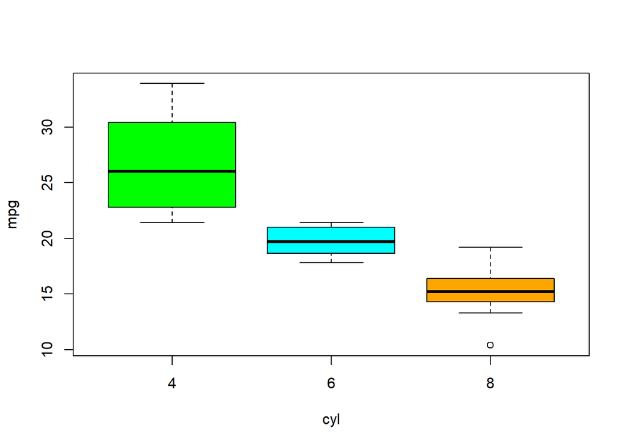

```r
# 상자그림 그리기
boxplot(mpg~cyl, data=mtcars,col=c("green","cyan","orange"))
```

```r
# 선형회귀모형 세우기
out<-lm(mpg~wt, data=mtcars)
summary(out)
```

```
##
## Call:
## lm(formula = mpg ~ wt, data = mtcars)
##
## Residuals:
##     Min      1Q  Median      3Q     Max
## -4.5432 -2.3647 -0.1252  1.4096  6.8727
##
## Coefficients:
##             Estimate Std. Error t value Pr(>|t|)
## (Intercept)  37.2851     1.8776  19.858  < 2e-16 ***
## wt           -5.3445     0.5591  -9.559 1.29e-10 ***
## ---
## Signif. codes:  0 '***' 0.001 '**' 0.01 '*' 0.05 '.' 0.1 ' ' 1
##
## Residual standard error: 3.046 on 30 degrees of freedom
## Multiple R-squared:  0.7528, Adjusted R-squared:  0.7446
## F-statistic: 91.38 on 1 and 30 DF,  p-value: 1.294e-10
```

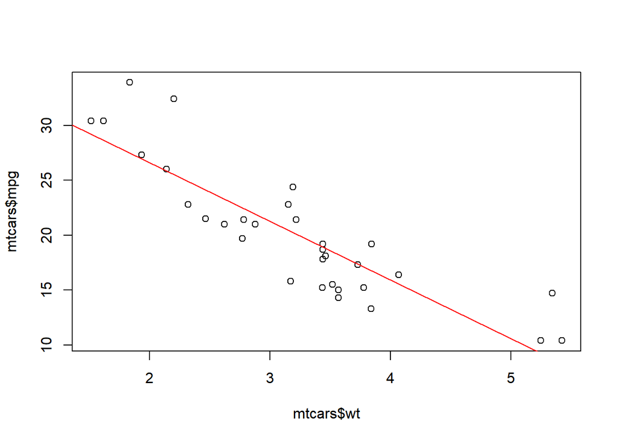

```r
# 선형회귀모형 분석결과 시각화
plot(mtcars$wt,mtcars$mpg)
lines(abline(coef(out), col="red"))
```

### 실시간 자료처리가 가능하다.

- 기상청에서 운영하는 실시간 관측자료를 수집할 수 있습니다.

주소 : http://www.weather.go.kr/weather/observation/currentweather.jsp

```r
# 실시간 기상자료 가져오기
if (!require(XML)) install.packages("XML") ;library(XML)
if (!require(RCurl)) install.packages("RCurl") ;library(RCurl)
```

```r
url2<-iconv(getURL("http://www.weather.go.kr/weather/observation/currentweather.jsp",
                   .encoding="euc-kr"),from="euc-kr",to='UTF-8')
tables<-as.data.frame(readHTMLTable(url2,encoding='UTF-8'))
names(tables)<-
  c("id","current","vis","cloud","l.cloud","Tcurrent","dew","sensible","prec","rh","dir","ws","hpa")

head(tables[,1:6], 10)
```

```
##        id current     vis cloud l.cloud Tcurrent
## 1    강릉         20 이상                   21.1
## 2  강진군            12.7                   18.8
## 3    강화         20 이상                   21.2
## 4    거제         20 이상                   21.4
## 5    거창            11.8                   16.7
## 6  경주시            18.1                   17.5
## 7    고산            17.2                   22.4
## 8    고창                                   19.5
## 9  고창군         20 이상                   19.8
## 10   고흥            17.3                   18.9
```

### 지도그림을 그릴 수 있다.

- 지도를 이용한 시각화를 위해선 arcGIS나 QGIS와 같은 프로그램이 필요합니다.
- R에서는 위의 프로그램을 사용하지 않고도 지도와 연관된 다양한 분석을 수행할 수 있습니다.

다음은 R을 이용하여 우리나라 행정구역을 인터넷에서 다운 받아 시각화하고,

한라산의 위치를 표시한 후, 한라산을 영문으로 표현한 예입니다.

```r
if (!require(raster)) install.packages("raster") ;library(raster)
```

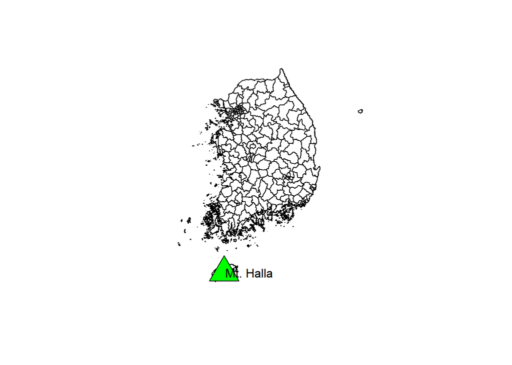

```r
kor<- getData('GADM', country='KOR', level=2)
plot(kor)

points(126.54,33.35, col="green", pch=17, cex=4)
points(126.54,33.35, col="black", pch=2, cex=4)
text(127.34,33.35, labels="Mt. Halla")
```

### 움직이는 그림을 그릴 수 있습니다.

```r
if (!require(leaflet)) install.packages("leaflet") ;library(leaflet)
m <- leaflet()
m <- addTiles(m)
m
```

[interactive chart not shown]

인터넷 주소만 알고 있으면 그림도 쉽게 가져 올 수 있습니다.

[figure not shown]

KERIS 입구사진

자 이제 R에 대해 자세히 알아보겠습니다.

- R 설치 : https://www.r-project.org/
- 왼쪽 메뉴에서 *CRAN* 선택 후 KOREA 아무곳이나 선택 후 파일을 다운 받으면 됩니다.
- R 에디터 설치 : https://www.rstudio.com/
- Desktop 버젼은 개인이 무료로 설치하여 이용할 수 있습니다.

R과 Rstudio를 설치 하신 후에는 Rstudio만 실행시키면 됩니다.

모든 수업은 Rstudio로 진행합니다.

인터넷을 검색하시면 설치하는 방법들을 쉽게 찾으실 수 있습니다.

참고하기 좋은 R 관련 사이트

- https://www.statmethods.net/
- http://www.sthda.com/english/
- https://www.datacamp.com/home
- https://www.r-graph-gallery.com/

이 외에도 많은 좋은 사이트들이 있습니다.

이 후의 강의는 Do it! 쉽게 배우는 R 데이터분석 교재를 중심으로 진행하겠습니다.

교재는 구매하지 않으셔도 괜찮습니다.

[figure not shown]

Do it! 쉽게 배우는 R 데이터분석